# Exploratory Data Analysis

Eliyahu B. Addess

```python
# imports
import numpy as np
import pandas as pd
import matplotlib.pyplot as plt
import seaborn as sns

sns.set_theme()
```

# Data

**Data Card:** https://www.kaggle.com/datasets/alexteboul/diabetes-health-indicators-dataset?select=diabetes_binary_health_indicators_BRFSS2015.csv

**Data set description on Kaggle:** "diabetes *binary* health *indicators* BRFSS2015.csv is a clean dataset of 253,680 survey responses to the CDC's BRFSS2015. The target variable Diabetes_binary has 2 classes. 0 is for no diabetes, and 1 is for prediabetes or diabetes. This dataset has 21 feature variables and is not balanced."

### Explanation of variables (from Kaggle)

**"**  
**Diabetes_binary:** 0 = no diabetes 1 = prediabetes or diabetes  
**HighBP:** 0 = no high BP 1 = high BP  
**HighChol:** 0 = no high cholesterol 1 = high cholesterol  
**CholCheck:** 0 = no cholesterol check in 5 years 1 = yes cholesterol check in 5 years  
**BMI:** Body Mass Index  
**Smoker:** Have you smoked at least 100 cigarettes in your entire life? [Note: 5 packs = 100 cigarettes] 0 = no 1 = yes  
**Stroke:** (Ever told) you had a stroke. 0 = no 1 = yes  
**HeartDiseaseorAttack:** coronary heart disease (CHD) or myocardial infarction (MI) 0 = no 1 = yes  
**PhysActivity:** physical activity in past 30 days - not including job 0 = no 1 = yes  
**Fruits:** Consume Fruit 1 or more times per day 0 = no 1 = yes  
**Veggies:** Consume Vegetables 1 or more times per day 0 = no 1 = yes  
**HvyAlcoholConsump:** (adult men >=14 drinks per week and adult women>=7 drinks per week) 0 = no 1 = yes  
**AnyHealthcare:** Have any kind of health care coverage, including health insurance, prepaid plans such as HMO, etc. 0 = no 1 = yes  
**NoDocbcCost:** Was there a time in the past 12 months when you needed to see a doctor but could not because of cost? 0 = no 1 = yes  
**GenHlth:** Would you say that in general your health is: scale 1-5 1 = excellent 2 = very good 3 = good 4 = fair 5 = poor  
**MentHlth:** days of poor mental health scale 1-30 days  
**PhysHlth:** physical illness or injury days in past 30 days scale 1-30  
**DiffWalk:** Do you have serious difficulty walking or climbing stairs? 0 = no 1 = yes  
**Sex:** 0 = female 1 = male  
**Age:** 13-level age category (_AGEG5YR see codebook) 1 = 18-24 9 = 60-64 13 = 80 or older  
**Education:** Education level (EDUCA see codebook) scale 1-6 1 = Never attended school or only kindergarten 2 = elementary etc.  
**Income:** Income scale (INCOME2 see codebook) scale 1-8 1 = less than \$10,000 5 = less than \$35,000 8 = \$75,000 or more  
**"**

**codebook link:** https://www.cdc.gov/brfss/annual_data/2015/pdf/codebook15_llcp.pdf

### Observations

# Inspect data

```python
# load data
diabetes = pd.read_csv('../data/diabetes_binary_health_indicators_BRFSS2015.csv')
diabetes.head()
```

|  | Diabetes_binary | HighBP | HighChol | CholCheck | BMI | Smoker | Stroke | HeartDiseaseorAttack | PhysActivity | Fruits | ... | AnyHealthcare | NoDocbcCost | GenHlth | MentHlth | PhysHlth | DiffWalk | Sex | Age | Education | Income |
| --- | --- | --- | --- | --- | --- | --- | --- | --- | --- | --- | --- | --- | --- | --- | --- | --- | --- | --- | --- | --- | --- |
| 0 | 0.0 | 1.0 | 1.0 | 1.0 | 40.0 | 1.0 | 0.0 | 0.0 | 0.0 | 0.0 | ... | 1.0 | 0.0 | 5.0 | 18.0 | 15.0 | 1.0 | 0.0 | 9.0 | 4.0 | 3.0 |
| 1 | 0.0 | 0.0 | 0.0 | 0.0 | 25.0 | 1.0 | 0.0 | 0.0 | 1.0 | 0.0 | ... | 0.0 | 1.0 | 3.0 | 0.0 | 0.0 | 0.0 | 0.0 | 7.0 | 6.0 | 1.0 |
| 2 | 0.0 | 1.0 | 1.0 | 1.0 | 28.0 | 0.0 | 0.0 | 0.0 | 0.0 | 1.0 | ... | 1.0 | 1.0 | 5.0 | 30.0 | 30.0 | 1.0 | 0.0 | 9.0 | 4.0 | 8.0 |
| 3 | 0.0 | 1.0 | 0.0 | 1.0 | 27.0 | 0.0 | 0.0 | 0.0 | 1.0 | 1.0 | ... | 1.0 | 0.0 | 2.0 | 0.0 | 0.0 | 0.0 | 0.0 | 11.0 | 3.0 | 6.0 |
| 4 | 0.0 | 1.0 | 1.0 | 1.0 | 24.0 | 0.0 | 0.0 | 0.0 | 1.0 | 1.0 | ... | 1.0 | 0.0 | 2.0 | 3.0 | 0.0 | 0.0 | 0.0 | 11.0 | 5.0 | 4.0 |

5 rows × 22 columns

```python
# get basic info
diabetes.info(verbose= False)
```

```
<class 'pandas.core.frame.DataFrame'>
RangeIndex: 253680 entries, 0 to 253679
Columns: 22 entries, Diabetes_binary to Income
dtypes: float64(22)
memory usage: 42.6 MB
```

```python
# missing values
diabetes.isna().sum()
```

```
Diabetes_binary         0
HighBP                  0
HighChol                0
CholCheck               0
BMI                     0
Smoker                  0
Stroke                  0
HeartDiseaseorAttack    0
PhysActivity            0
Fruits                  0
Veggies                 0
HvyAlcoholConsump       0
AnyHealthcare           0
NoDocbcCost             0
GenHlth                 0
MentHlth                0
PhysHlth                0
DiffWalk                0
Sex                     0
Age                     0
Education               0
Income                  0
dtype: int64
```

```python
diabetes.columns
```

```
Index(['Diabetes_binary', 'HighBP', 'HighChol', 'CholCheck', 'BMI', 'Smoker',
       'Stroke', 'HeartDiseaseorAttack', 'PhysActivity', 'Fruits', 'Veggies',
       'HvyAlcoholConsump', 'AnyHealthcare', 'NoDocbcCost', 'GenHlth',
       'MentHlth', 'PhysHlth', 'DiffWalk', 'Sex', 'Age', 'Education',
       'Income'],
      dtype='object')
```

```python
# quick description of data
diabetes.describe().T.drop('count', axis = 1)
```

|  | mean | std | min | 25% | 50% | 75% | max |
| --- | --- | --- | --- | --- | --- | --- | --- |
| Diabetes_binary | 0.139333 | 0.346294 | 0.0 | 0.0 | 0.0 | 0.0 | 1.0 |
| HighBP | 0.429001 | 0.494934 | 0.0 | 0.0 | 0.0 | 1.0 | 1.0 |
| HighChol | 0.424121 | 0.494210 | 0.0 | 0.0 | 0.0 | 1.0 | 1.0 |
| CholCheck | 0.962670 | 0.189571 | 0.0 | 1.0 | 1.0 | 1.0 | 1.0 |
| BMI | 28.382364 | 6.608694 | 12.0 | 24.0 | 27.0 | 31.0 | 98.0 |
| Smoker | 0.443169 | 0.496761 | 0.0 | 0.0 | 0.0 | 1.0 | 1.0 |
| Stroke | 0.040571 | 0.197294 | 0.0 | 0.0 | 0.0 | 0.0 | 1.0 |
| HeartDiseaseorAttack | 0.094186 | 0.292087 | 0.0 | 0.0 | 0.0 | 0.0 | 1.0 |
| PhysActivity | 0.756544 | 0.429169 | 0.0 | 1.0 | 1.0 | 1.0 | 1.0 |
| Fruits | 0.634256 | 0.481639 | 0.0 | 0.0 | 1.0 | 1.0 | 1.0 |
| Veggies | 0.811420 | 0.391175 | 0.0 | 1.0 | 1.0 | 1.0 | 1.0 |
| HvyAlcoholConsump | 0.056197 | 0.230302 | 0.0 | 0.0 | 0.0 | 0.0 | 1.0 |
| AnyHealthcare | 0.951053 | 0.215759 | 0.0 | 1.0 | 1.0 | 1.0 | 1.0 |
| NoDocbcCost | 0.084177 | 0.277654 | 0.0 | 0.0 | 0.0 | 0.0 | 1.0 |
| GenHlth | 2.511392 | 1.068477 | 1.0 | 2.0 | 2.0 | 3.0 | 5.0 |
| MentHlth | 3.184772 | 7.412847 | 0.0 | 0.0 | 0.0 | 2.0 | 30.0 |
| PhysHlth | 4.242081 | 8.717951 | 0.0 | 0.0 | 0.0 | 3.0 | 30.0 |
| DiffWalk | 0.168224 | 0.374066 | 0.0 | 0.0 | 0.0 | 0.0 | 1.0 |
| Sex | 0.440342 | 0.496429 | 0.0 | 0.0 | 0.0 | 1.0 | 1.0 |
| Age | 8.032119 | 3.054220 | 1.0 | 6.0 | 8.0 | 10.0 | 13.0 |
| Education | 5.050434 | 0.985774 | 1.0 | 4.0 | 5.0 | 6.0 | 6.0 |
| Income | 6.053875 | 2.071148 | 1.0 | 5.0 | 7.0 | 8.0 | 8.0 |

```python
# diabetes totals
diabetes_vals = diabetes.Diabetes_binary.value_counts()
print(diabetes_vals)
```

```
0.0    218334
1.0     35346
Name: Diabetes_binary, dtype: int64
```

```python
print('Percent Diabetic:', (diabetes_vals[1]/ diabetes.shape[0]).round(2))
print('Percent Not Diabetic:', (diabetes_vals[0]/ diabetes.shape[0]).round(2))
```

```
Percent Diabetic: 0.14
Percent Not Diabetic: 0.86
```

Ok, so about 14% of the sample are diabetic. This is reasonably close to the google search for percent of population who are diabetic which was around 11%.

# EDA of Smoker and Diabetes Association

After spending some time working with this data set, I realized that most of the variables may not be treatments in the sense of causal inference. There is no record that the habits described in the data set took place prior to the onset of diabetes. Nonetheless, for academic purposes, I continue this project. We begin with the Smoker variable.  
We are interested in investigating the relationship between smoking and diabetes. We will first look into the association and then causation.

```python
df_smoker = diabetes[['Diabetes_binary', 'Smoker',]]
df_smoker.head()
```

|  | Diabetes_binary | Smoker |
| --- | --- | --- |
| 0 | 0.0 | 1.0 |
| 1 | 0.0 | 1.0 |
| 2 | 0.0 | 0.0 |
| 3 | 0.0 | 0.0 |
| 4 | 0.0 | 0.0 |

```python
# for smoker variable calculate percent diabetic
smoker_diabetic = df_smoker.groupby('Smoker').mean()
smoker_diabetic
```

| Smoker | Diabetes_binary |
| --- | --- |
| 0.0 | 0.120553 |
| 1.0 | 0.162929 |

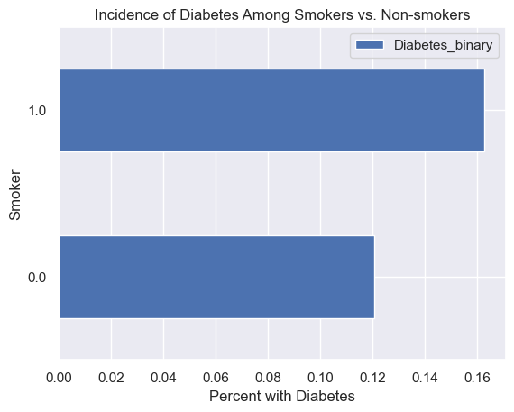

```python
# plot
smoker_diabetic.plot(kind = 'barh')
plt.title('Incidence of Diabetes Among Smokers vs. Non-smokers')
plt.xlabel('Percent with Diabetes')
```

**Observation:** We see that among smokers there is a higher incidence of diabetes, with 16% of smokers having diabetes, while only 12% of nonsmokers have diabetes.

## Association

Wasserman (p. 253) defines the association as $\alpha = E(Y|X=1) - E(Y|X = 0)$, which can be estimated by $\bar{Y_1} - \bar{Y_0}$. In our case, smoking is the binary treatment variable $X$ and diabetes is the binary response $Y$.

```python
alpha = smoker_diabetic.loc[1] - smoker_diabetic.loc[0]
alpha
```

```
Diabetes_binary    0.042376
dtype: float64
```

This is ,admittedly, a small association.

# Diabetes Type 2 analysis

Our original analysis did not differentiate between type 1 and type 2 diabetes. It also did not take gestational diabetes into account. However, we should make this distinction because type 2 diabetes is developed over many years and is thought to be caused by unhealthy habits. Type 1 diabetes is developed early on and not necessarily associated with lifestyle risk factors( https://www.cdc.gov/diabetes/basics/risk-factors.html).

Xie(2019) used BRFSS data to analyze diabetes type 2 risk factors, and assumed that anyone greater than 30 and not pregnant had type 2. We will follow a similar convention. Our data set does not include a pregnant variable, so we will default to subsetting to men over 30.

Note that age is a 13 level categorical variable with 3 corresponding to age 30-34 https://www.kaggle.com/datasets/alexteboul/diabetes-health-indicators-dataset/discussion/295407.

```python
# subset data
diabetes2 = diabetes.loc[(diabetes.Age >= 3) & (diabetes.Sex == 1),:]
```

```python
df_smoker2 = diabetes2[['Diabetes_binary', 'Smoker',]]
df_smoker2.head()
```

|  | Diabetes_binary | Smoker |
| --- | --- | --- |
| 5 | 0.0 | 1.0 |
| 9 | 0.0 | 0.0 |
| 10 | 1.0 | 1.0 |
| 17 | 1.0 | 1.0 |
| 19 | 0.0 | 0.0 |

```python
# for smoker variable calculate percent diabetic
smoker_diabetic2 = df_smoker2.groupby('Smoker').mean()
smoker_diabetic2
```

| Smoker | Diabetes_binary |
| --- | --- |
| 0.0 | 0.133011 |
| 1.0 | 0.186671 |

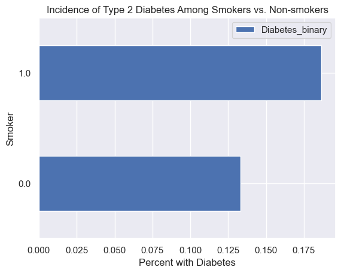

```python
# plot
smoker_diabetic2.plot(kind = 'barh')
plt.title('Incidence of Type 2 Diabetes Among Smokers vs. Non-smokers')
plt.xlabel('Percent with Diabetes')
```

```python
# association
alpha = smoker_diabetic2.loc[1] - smoker_diabetic2.loc[0]
alpha
```

```
Diabetes_binary    0.05366
dtype: float64
```

**Ok, now we see a slightly higher association of about 0.05.**